# Introduction to INLA

Ellis Valentiner

October 24, 2014

```r
rm(list = ls(all.names = TRUE))

library(INLA)
library(R2BayesX)
library(RColorBrewer)
library(stargazer)
library(ggplot2)
```

### Overview of Multilevel Modeling

Extension of regression for data with group structures, where coefficients can vary by group.

- Nested data
- Repeated measures
- Time-series cross sections
- Other non-nested structures

Some examples of data with group structures:

- Children within classrooms
- Patients within a clinical treatment
- Repeated measures for the same individual

Some advantages:

- accounts for variation at multiple levels when estimating group-level coefficients
- model variation among subject-level coefficients
- estimate coefficients for specific groups

### Bayesian Models

Considers parameters as random variables that are characterized by a prior distribution. This prior distribution is combined with the traditional likelihood to obtain the posterior distribution of the parameter of interest on which the statistical inference is based.

### Installing INLA

http://www.r-inla.org/download

```r
source("http://www.math.ntnu.no/inla/givemeINLA.R")
```

INLA **requires** `sp` and suggests `numDeriv`, `Rgraphviz` (from Bioconductor), `fields`, `rgl`, `mvtnorm`, `multicore`, and `pixmap`

### Latent Models

| Model | Name |
| --- | --- |
| Independent random variables | `iid` |
| Linear | `linear` |
| Constrained linear | `clienar` |
| Random walk of order 1 | `rw1` |
| Random walk of order 2 | `rw2` |
| Continuous random walk of order 2 | `crw2` |
| Model for seasonal variation | `seasonal` |
| Model for spatial effect | `besag` |
| Model for spatial effect | `besagproper` |

### Example: Sleep Study

```r
#for lmer() and sleepstudy
library(lme4)
system.time(fm1 <- lmer(Reaction ~ Days + (Days | Subject), data = sleepstudy))
```

```
##    user  system elapsed
##   0.077   0.007   0.103
```

```r
system.time(fm2 <- inla(Reaction ~ Days + f(Subject), data = sleepstudy))
```

```
##    user  system elapsed
##   0.328   0.064   0.423
```

```r
summary(fm1)
```

```
## Linear mixed model fit by REML ['lmerMod']
## Formula: Reaction ~ Days + (Days | Subject)
##    Data: sleepstudy
##
## REML criterion at convergence: 1744
##
## Scaled residuals:
##    Min     1Q Median     3Q    Max
## -3.954 -0.463  0.023  0.463  5.179
##
## Random effects:
##  Groups   Name        Variance Std.Dev. Corr
##  Subject  (Intercept) 612.1    24.74
##           Days         35.1     5.92    0.07
##  Residual             654.9    25.59
## Number of obs: 180, groups: Subject, 18
##
## Fixed effects:
##             Estimate Std. Error t value
## (Intercept)   251.41       6.82    36.8
## Days           10.47       1.55     6.8
##
## Correlation of Fixed Effects:
##      (Intr)
## Days -0.138
```

```r
summary(fm2)
```

```
##
## Call:
## "inla(formula = Reaction ~ Days + f(Subject), data = sleepstudy)"
##
## Time used:
##  Pre-processing    Running inla Post-processing           Total
##          0.2118          0.1518          0.0413          0.4049
##
## Fixed effects:
##               mean    sd 0.025quant 0.5quant 0.975quant   mode kld
## (Intercept) 251.47 6.420    238.856   251.47     264.08 251.47   0
## Days         10.45 1.202      8.089    10.45      12.81  10.45   0
##
## Random effects:
## Name   Model
##  Subject   IID model
##
## Model hyperparameters:
##                                         mean    sd      0.025quant
## Precision for the Gaussian observations  0.0005  0.0000  0.0004
## Precision for Subject                   13.2691  1.4687 10.2941
##                                         0.5quant 0.975quant mode
## Precision for the Gaussian observations  0.0005   0.0005     0.0005
## Precision for Subject                   13.3373  15.9805    13.6845
##
## Expected number of effective parameters(std dev): 2.005(9e-04)
## Number of equivalent replicates : 89.80
##
## Marginal Likelihood:  -981.46
```

### Example: Munich

Semiparametric regression model with Gaussian data and additional spatial effect. Example 4.2.2 from “Gaussian Markov Random Fields: Theory and Applications” by H. Rue and L. Held

```r
#load the data
data(Munich)

## Note that here we what to have an estimator of the effect of `year`
## also the for years where we have no observation, therefore we give a
## vector with all possible values assumed by the covariate `year`, that
## is seq(1918,2001)

formula <- rent ~ f(location, model="besag", graph = "Munich/munich.graph",
                      initial = 1, param = c(1, 0.01)) +
                      f(year, model = "rw2", values = seq(1918, 2001),
                        param = c(1, 0.01)) +
                      f(floor.size, model = "rw2", param=c(1, 0.01)) +
                      Gute.Wohnlage + Beste.Wohnlage + Keine.Wwv + Keine.Zh +
                      Kein.Badkach  + Besond.Bad + Gehobene.Kueche +
                      zim1 + zim2 + zim3 + zim4 + zim5 + zim6 -1

mod <- inla(formula, data = Munich, verbose = TRUE,
                  control.family = list(initial = -1),
                  control.predictor = list(initial = 12),
                  control.inla = list(h = 1e-4))
```

```r
fixed.effects <- mod$summary.fixed
colnames(fixed.effects) <- c('Mean', 'SD', 'Q0.025', 'Median', 'Q0.975', 'Mode', 'KLD')
stargazer(fixed.effects, type = 'html', title = 'Fixed effects')
```

**Fixed effects**

|  | Mean | SD | Q0.025 | Median | Q0.975 | Mode | KLD |
| --- | --- | --- | --- | --- | --- | --- | --- |
| Gute.Wohnlage | 0.607 | 0.109 | 0.392 | 0.607 | 0.819 | 0.608 | 0 |
| Beste.Wohnlage | 1.791 | 0.316 | 1.170 | 1.791 | 2.411 | 1.791 | 0 |
| Keine.Wwv | -1.933 | 0.278 | -2.479 | -1.933 | -1.387 | -1.933 | 0 |
| Keine.Zh | -1.380 | 0.191 | -1.755 | -1.380 | -1.006 | -1.380 | 0 |
| Kein.Badkach | -0.558 | 0.115 | -0.783 | -0.558 | -0.334 | -0.558 | 0 |
| Besond.Bad | 0.481 | 0.160 | 0.166 | 0.481 | 0.796 | 0.481 | 0 |
| Gehobene.Kueche | 1.144 | 0.174 | 0.802 | 1.144 | 1.486 | 1.144 | 0 |
| zim1 | 8.141 | 0.262 | 7.627 | 8.141 | 8.655 | 8.141 | 0 |
| zim2 | 8.400 | 0.186 | 8.035 | 8.400 | 8.765 | 8.400 | 0 |
| zim3 | 8.195 | 0.170 | 7.861 | 8.195 | 8.529 | 8.194 | 0 |
| zim4 | 7.777 | 0.190 | 7.405 | 7.777 | 8.151 | 7.777 | 0 |
| zim5 | 7.926 | 0.329 | 7.281 | 7.926 | 8.571 | 7.926 | 0 |
| zim6 | 7.705 | 0.597 | 6.533 | 7.705 | 8.876 | 7.705 | 0 |

```r
hyperparameters <- mod$summary.hyperpar
colnames(hyperparameters) <- c('Mean', 'SD', 'Q0.025', 'Median', 'Q0.975', 'Mode')
stargazer(hyperparameters, type = 'html', title = 'Hyperparameters')
```

**Hyperparameters**

|  | Mean | SD | Q0.025 | Median | Q0.975 | Mode |
| --- | --- | --- | --- | --- | --- | --- |
| Precision for the Gaussian observations | 0.274 | 0.009 | 0.256 | 0.274 | 0.292 | 0.275 |
| Precision for location | 2.627 | 0.967 | 1.269 | 2.449 | 5.005 | 2.133 |
| Precision for year | 351.500 | 161.500 | 116.300 | 327.000 | 732.900 | 268.100 |
| Precision for floor.size | 457.200 | 190.600 | 188.300 | 423.400 | 922.100 | 362.100 |

### Example: Zambia

Semiparametric regression on Gaussian data with additional spatial effect. Example taken from the BayesX manual, for details see `BayesX`.

```r
data(Zambia)

#load map
map <- suppressWarnings(read.bnd("Zambia/zambia.bnd"))
```

```
## Note: map consists of 57 polygons
## Note: map consists of 57 regions
## Reading map ... finished
```

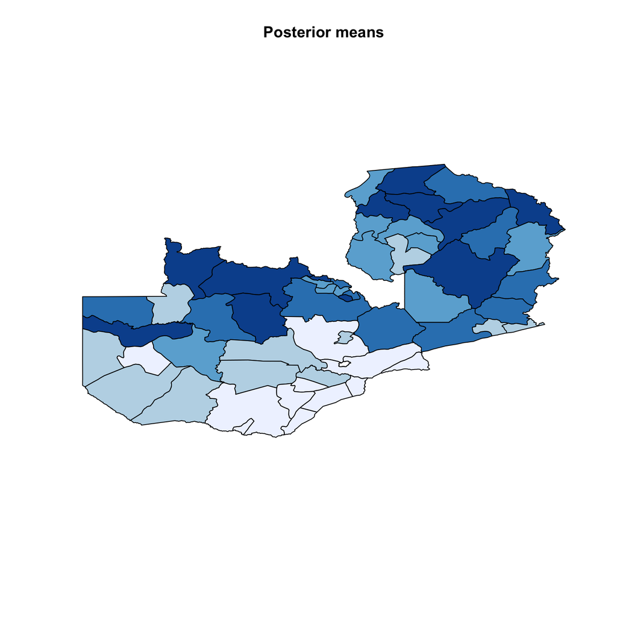

```r
plotMap = function(map, x, nbreaks = 5, theme = "Blues", ...){
  pal  <- brewer.pal(n = nbreaks, name = theme)
  brks <- quantile(x, probs = seq(0, 1, 1 / nbreaks))
  cols <- cut(x, breaks = brks, labels = pal)
  plot(map, col = as.character(cols), ...)
}

# add one column for the unstructured spatial effect
Zambia$distr.unstruct  =  Zambia$district

formula <- hazstd ~ f(inla.group(bmi), model = "rw2") + f(agc, model = "rw2") +
                        f(district, model = "besag", graph = "Zambia/zambia.graph", param = c(1, 0.01)) +
                        f(distr.unstruct, model = "iid", param = c(1, 0.01)) +
                        rcw + edu1 + edu2 + tpr + sex

mod.zambia <- inla(formula, data = Zambia, control.fixed = list(prec.intercept = 0.001, prec = 0.001), verbose=TRUE)

#map posterior means
posterior.means <- mod.zambia$summary.random$district$mean
plotMap(map, posterior.means)
title(main = "Posterior means")
```